# [STA1] : Statistiques univariée

GEO UNIV’R Tunisie 2024

Auteur·rice

Claude Grasland

Date de publication

2024-05-13

# 1 PREPARATION DES DONNEES

Nous allons importer un fichier de données portant sur les revenus de 17000 ménages tunisiens en 2021. Il est tiré de l’enquête consommation et revenu de l’INS dont on trouvera la description détaillée en [cliquant ici](https://www.ins.tn/enquetes/enquete-nationale-sur-le-budget-la-consommation-et-le-niveau-de-vie-des-menages-2021)

**Télécharger le jeux de données**

- [ENQ-TUN-2021](https://github.com/worldregio/geounivr2024/raw/refs/heads/main/datazip/ENQ-TUN-2021.zip)

## Importation des données

On commence par charger les données contenues dans le fichier *enq_INS_conso_menages_2021.RDS* à l’aide de la fonction `readRDS()` qui permet de lire les fichiers sauvegardés sans le format interne de R et on affiche les 6 premières lignes

```r
# Importe les données au format interne de R
base<-readRDS("data/ENQ-TUN-2021/enq_INS_conso_menages_2021.RDS")
head(base)
```

```
  id reg    mil   sex age     mat        ins      csp nbp   pvr  rev
1  1  GT urbain homme  59   marie   primaire retraité   6 FALSE 5103
2  2  GT urbain homme  52   marie   primaire  employé   5 FALSE 5486
3  3  GT urbain femme  34 divorce secondaire  chomeur   2 FALSE 5962
4  4  GT urbain homme  65   marie   primaire  inactif   2 FALSE 3699
5  5  GT urbain homme  35   marie secondaire  ouvrier   4 FALSE 5058
6  6  GT urbain homme  43   marie   primaire  ouvrier   5 FALSE 3741
```

## Liste des variables

On a légèrement changé le fichier initial de l’INS en simplifiant les noms des variables et en fusionnant certaines modalités. Les variables proposées sont les suivantes :

- id : identifiant du ménages de 1 à 17114
- reg : région de résidence (NE, NO, CE, CO, SE, SO + Grand Tunis)
- mil : milieu de résidence (urbain ou rural)
- sex : sexe du chef de ménage
- age : age du chef de ménage
- mat : situation matrimoniale (célbataire, marié, veuf, divorcé)
- ins : instruction du chef de ménage (aucune, primaire, secondaire, supérieur)
- csp : catégorie socio professionnelle du chef de ménage (simplifiée)
- nbp : nombre de personnes composant le ménage
- pauv: situation de pauvreté selon les critères de l’INS (Oui/Non)
- rev : revenu moyen par personnes en DT / an

## Selection du tableau à analyser

On suppose qu’on ne s’intéresse qu’à quelques variables

```r
don<-base[,c("reg","mil","sex", "age","ins","pvr","rev")]
head(don)
```

```
  reg    mil   sex age        ins   pvr  rev
1  GT urbain homme  59   primaire FALSE 5103
2  GT urbain homme  52   primaire FALSE 5486
3  GT urbain femme  34 secondaire FALSE 5962
4  GT urbain homme  65   primaire FALSE 3699
5  GT urbain homme  35 secondaire FALSE 5058
6  GT urbain homme  43   primaire FALSE 3741
```

## Résumé rapide

On effectue un résumé rapide du tableau à l’aide de la fonction `summary()`:

```r
summary(don)
```

```
 reg           mil           sex             age                 ins
 GT:3944   urbain:10836   homme:13996   Min.   : 19.00   aucun     :3742
 NE:2458   rural : 6278   femme: 3118   1st Qu.: 46.00   primaire  :6979
 NO:2502                                Median : 56.00   secondaire:4647
 CE:2862                                Mean   : 56.34   supérieur :1746
 CO:2330                                3rd Qu.: 66.00
 SE:1845                                Max.   :109.00
 SO:1173
    pvr               rev
 Mode :logical   Min.   :   185
 FALSE:14665     1st Qu.:  3035
 TRUE :2449      Median :  4429
                 Mean   :  5519
                 3rd Qu.:  6496
                 Max.   :526271
```

# 2. ANALYSE D’UNE VARIABLE QUALITATIVE (type *factor* ou *logic*)

## Choix de la variables

Nous allons prendre comme exemple la variable ins que l’on va extraire du tableau pour en faire un vecteur X qui est de type factor

```r
X <-don$ins
class(X)
```

```
[1] "factor"
```

## 2.1 tableau de dénombrement

Pour dénomber une variable qualitative, on utilise l’instruction **table()** qui crée un objet particulier qui n’est ni un *data.frame*, ni une *matrix*.

### création et affichage du tableau

```r
tab<-table(X)
tab
```

```
X
     aucun   primaire secondaire  supérieur
      3742       6979       4647       1746
```

## 2.1 tableau de dénombrement

### Ajout du total

Un objet de type table peut être manipulé par des fonctions spéciales comme *addmargins()*

```r
tab2<-addmargins(tab)
tab2
```

```
X
     aucun   primaire secondaire  supérieur        Sum
      3742       6979       4647       1746      17114
```

### Transformation en fréquence

On peut également passer en fréquence avec la fonction *prop.table()*

```r
tab3<-prop.table(tab)
tab3
```

```
X
     aucun   primaire secondaire  supérieur
 0.2186514  0.4077948  0.2715321  0.1020217
```

### Transformation en pourcentage

On peut finalement afficher le résultat sous une forme élégante :

```r
tab4<-100*addmargins(tab3)
tab4
```

```
X
     aucun   primaire secondaire  supérieur        Sum
  21.86514   40.77948   27.15321   10.20217  100.00000
```

## 2.3 Visualiation

La fonction **plot()** s’applique à la plupart de objets R. Elle s’adapte au type d’objet et va chercher la fonction la plus adaptée au type de variable. Dans le cas d’une variable de type factor, la fonction *plot()* appelle en réalité la fonction *barplot()* après avoir effectué le dénombrement avec *table()*

### Diagramme en bâtons

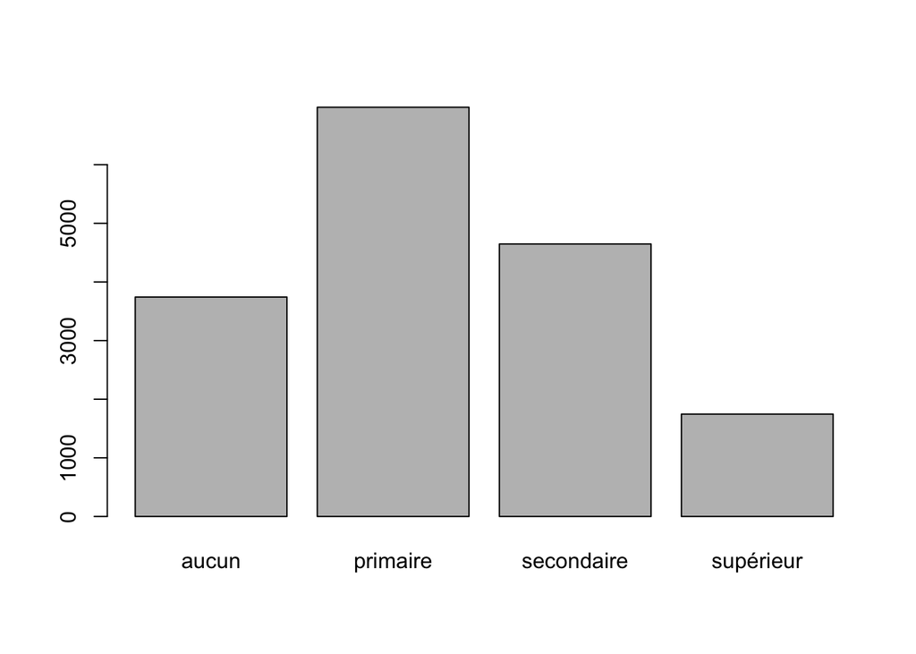

```r
# Ecriture simple
plot(X)
```

```r
# Ecriture équivalente
# barplot(table(X))
```

### plot amélioré

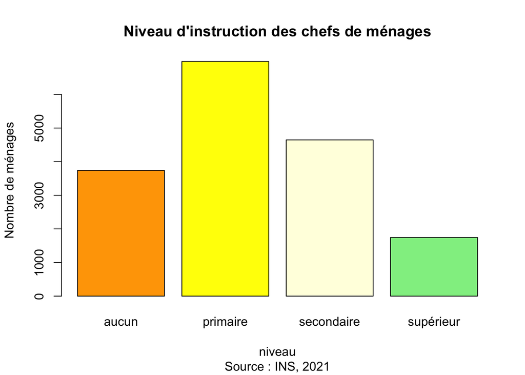

```r
plot(X,col=c("orange","yellow",
             "lightyellow","lightgreen"),
     main= "Niveau d'instruction des chefs de ménages",
     xlab = "niveau",
     ylab = "Nombre de ménages",
     sub = "Source : INS, 2021")
```

# 3. ANALYSE D’UNE VARIABLE QUANTITATIVE

## 3.1 Valeurs centrales et paramètres de dispersion

### fonctions élémentaires

Une variable numérique peut faire l’objet d’un ensemble de résumés statistiques à l’aide de fonctions élémentaires

- **min()** : minimum
- **max()** : maximum
- **mean()** : moyenne
- **sd()** : écart-type
- **sum()** : somme

On va prendre l’exemple du revenu moyen par habitant

```r
X <- don$rev
min(X)
```

```
[1] 185
```

```r
max(X)
```

```
[1] 526271
```

```r
mean(X)
```

```
[1] 5519.385
```

```r
sd(X)
```

```
[1] 7036.663
```

### quantiles

Pour calculer les quantiles on peut utiliser la fonction **quantile()** en paramétrant la valeur de fréquence cumulée ascendante

- **quantile(X,0)** : minimum
- **quantile(X,0.10)** : D1 (premier décile)
- **quantile(X,0.25)** : Q1 (premier quartile)
- **quantile(X,0.5)** : Q2 (médiane)
- **quantile(X,0.75)** : Q3 (troisième quartile)
- **quantile(X,0.90)** : D9 (dernier décile)
- **quantile(X,1)** : maximum

### quantiles

```r
X<-don$rev
quantile(X,0.5)
```

```
 50%
4429
```

```r
sel<-c(0,0.25,0.5,0.75,1)
quantile(X,sel)
```

```
       0%       25%       50%       75%      100%
   185.00   3035.00   4429.00   6495.75 526271.00
```

```r
sel<-c(0,0.1,0.2,0.3,0.4,0.5,0.6,0.7,0.8,0.9,1)
quantile(X,sel)
```

```
      0%      10%      20%      30%      40%      50%      60%      70%
   185.0   2143.6   2757.0   3304.0   3854.0   4429.0   5104.0   5941.0
     80%      90%     100%
  7151.0   9480.4 526271.0
```

## 3.2 Tableau de dénombrement (discrétisation)

Une variable quantitative peut être discrétisée avec **cut()**. Elle devient alors un facteur qu’on peut dénomber avec **table()**

```r
XQ<-cut(don$rev, c(0, 500, 1000, 2000, 5000, 10000, 20000, 50000, 1000000))
table(XQ)
```

```
XQ
      (0,500]   (500,1e+03] (1e+03,2e+03] (2e+03,5e+03] (5e+03,1e+04]
            7            92          1269          8664          5586
(1e+04,2e+04] (2e+04,5e+04] (5e+04,1e+06]
         1333           134            29
```

## 3.3 Boîte à moustaches

La fonction **boxplot()** permet de visualiser une distribution sous forme de boîte à moustache où l’on repère facilement :

- la médiane
- les quartiles Q1 et Q3
- le minimum et le maximum
- les valeurs extrêmes

### Boxplot simple

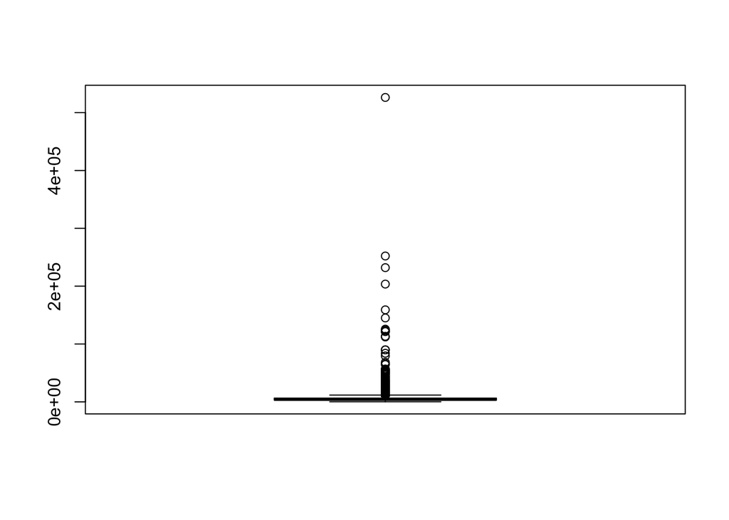

```r
boxplot(X)
```

### Boxplot améliorée

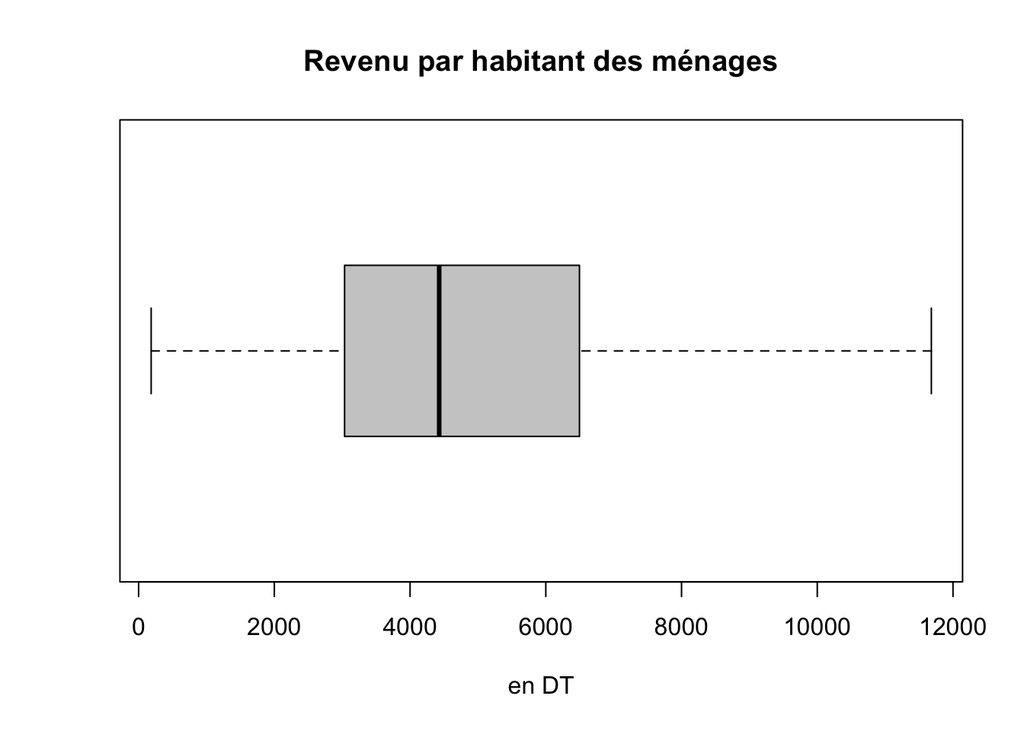

```r
boxplot(X,horizontal = TRUE,
        col = "gray80",
        main = "Revenu par habitant des ménages",
        xlab = "en DT",
        outline = F
        )
```

## 3.4 Histogramme

Dans le cas d’une variable **quantitative continue**, la visualisation la plus logique est l’histogramme que l’on peut tracer avec la fonction **hist()**. Celle-ci comporte plusieurs paramètres que l’on peut visualiser en allant dans l’onglet *Help* et en tapant le nom de la fonction. On retiendra surtout ici

- **breaks** : contrôle le choix des classes
- **probability** : affiche la densité et non pas l’effectif des classes

### Histogramme simple

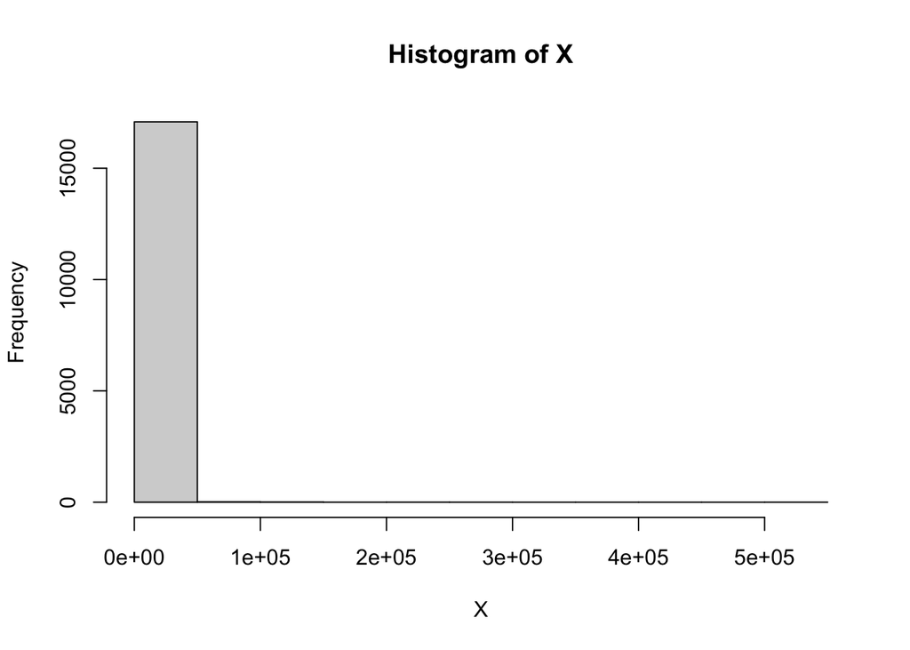

```r
X<-don$rev
hist(X)
```

### Histogramme amélioré

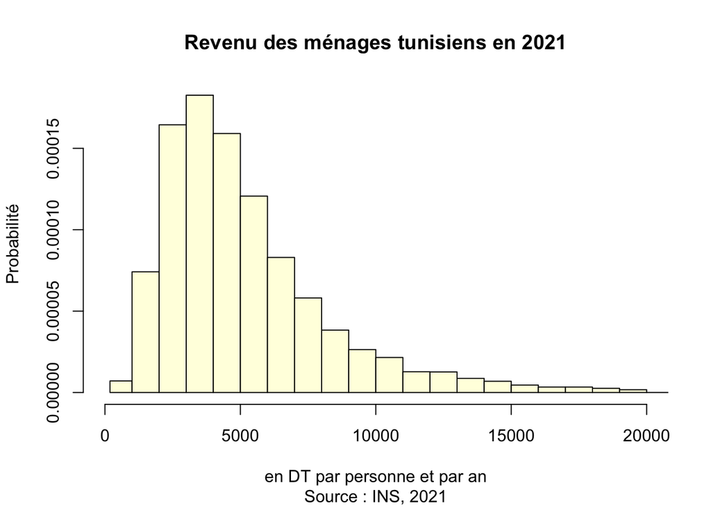

```r
X<-don$rev

# Choix des classes
mybreaks<-c(min(X),1000,2000,3000,4000,5000,6000,7000,8000,9000,10000,
                       11000, 12000, 13000, 14000, 15000,16000,
            17000, 18000, 19000, 20000, max(X))

hist(X,
     breaks = mybreaks,
     col="lightyellow",
     main = "Revenu des ménages tunisiens en 2021",
     sub = "Source : INS, 2021",
     xlab = "en DT par personne et par an",
     ylab = "Probabilité",
     xlim=c(0,20000))
```

### Histogramme superbe

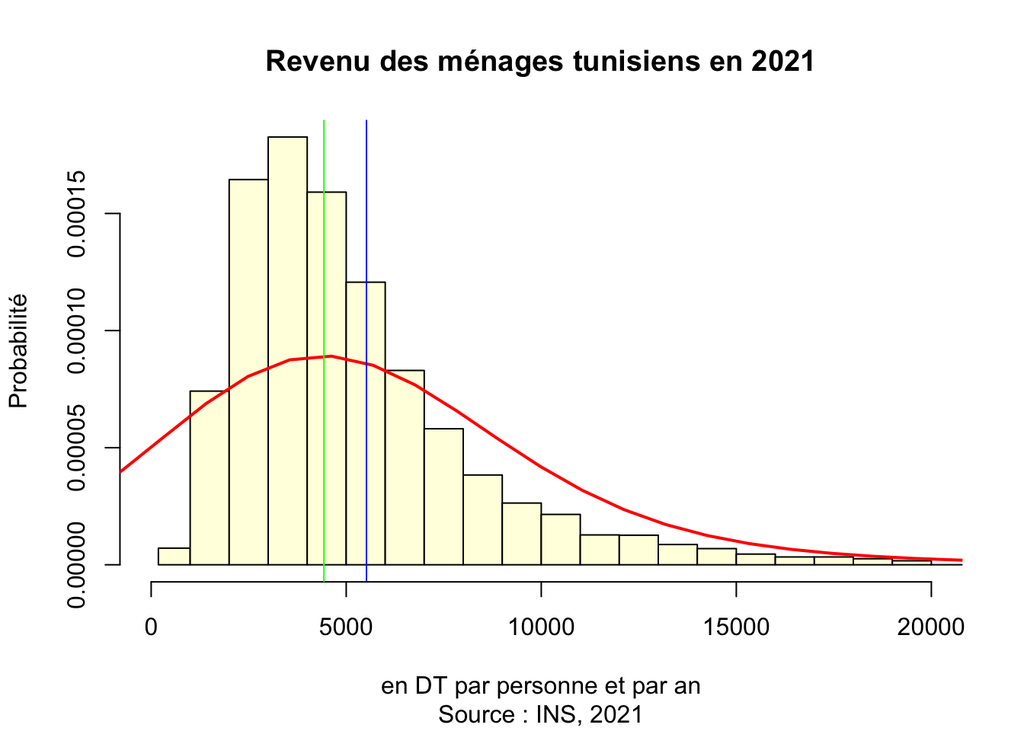

```r
X<-don$rev

# Choix des classes
mybreaks<-c(min(X),1000,2000,3000,4000,5000,6000,7000,8000,9000,10000,
                       11000, 12000, 13000, 14000, 15000,16000,
            17000, 18000, 19000, 20000, max(X))

hist(X,
     breaks = mybreaks,
     col="lightyellow",
     main = "Revenu des ménages tunisiens en 2021",
     sub = "Source : INS, 2021",
     xlab = "en DT par personne et par an",
     ylab = "Probabilité",
     xlim=c(0,20000))

# Ajout d'une courbe de Probabilité lissée
lines(density(X,
              bw = sd(X)/2),
              col="red", lwd=2)

# Ajout de la moyenne et de la médiane
abline(v=mean(X), col="blue")
abline(v=median(X), col="green")
```

# 4. A VOUS DE JOUER !

## Objectif

Vous allez maintenant essayer de reprendre les programmes précédents en analysant successivement une variable qualitative et une variable quantitative.